# Multilayer Perceptron

Next 2 tests will be about regression of function $y=x^2$. In the first case we will test neural networks with one hidden layer having different neuron counts.

```
1 neuron, last mean error: 342.9495887062549
```

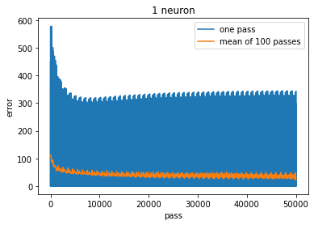

```
2 neurons, last mean error: 0.05990488621187058
```

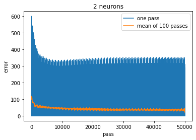

```
4 neurons, last mean error: 1.3655126694890813
```

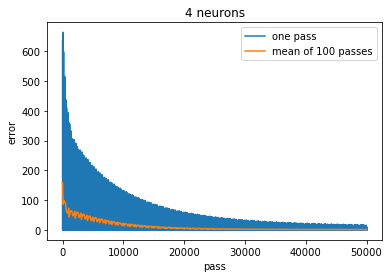

```
8 neurons, last mean error: 0.35243398667747505
```

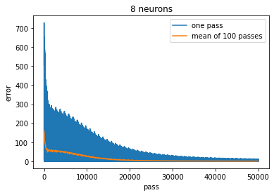

```
16 neurons, last mean error: 0.2817700619063955
```

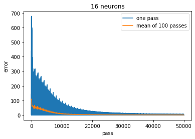

```
32 neurons, last mean error: 0.004189185536857843
```

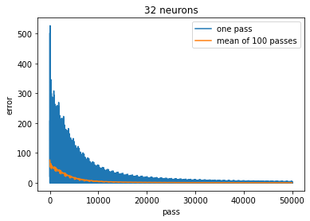

```
64 neurons, last mean error: 0.12047444670288812
```

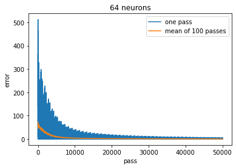

```
128 neurons, last mean error: 0.009829762997894897
```

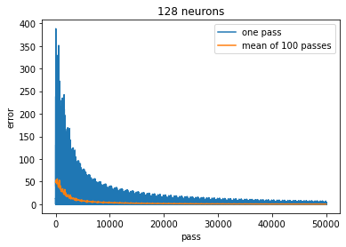

```
256 neurons, last mean error: 0.09903327691733277
```

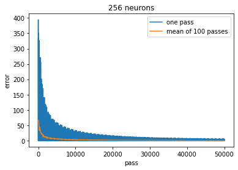

```
512 neurons, last mean error: 0.2383434005731815
```

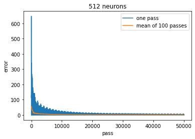

```python
layers = [[1],
          [2],
          [4],
          [8],
          [16],
          [32],
          [64],
          [128],
          [256],
          [512]]

for ind, layer_type in enumerate(layers):
    mlp = Perceptron(problem_type=Perceptron.ProblemType.Regression,
                     hidden_layers=layer_type,
                     activation=sigmoid,
                     dActivation=dSigmoid,
                     batch_size=3,
                     learning_rate=0.001,
                     momentum=0.1,
                     epochs=50,
                     bias=True)
    mlp.load("data\quadratic1_train.csv")
    losses = mlp.train()
    st = f'{2 ** ind} neurons' if ind != 0 else f'{2 ** ind} neuron'
    print(f'{st}, last mean error: {losses[-1]}')
    plot_errors_title(losses, st)
```

In this case introducing additional neurons seems to be improving the performance slightly.

The next test will use the same data as previous one but neural networks will have 2 hidden layers.

```
2 hidden layers, 1 neuron each, last mean error: 8.014100789018444
```

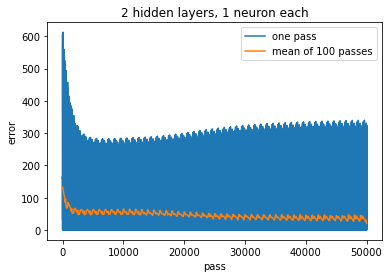

```
2 hidden layers, 2 neurons each, last mean error: 1.2526283551757031
```

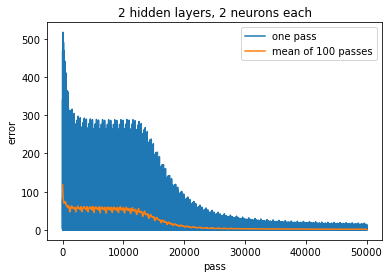

```
2 hidden layers, 4 neurons each, last mean error: 0.09639026594312601
```

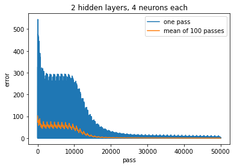

```
2 hidden layers, 8 neurons each, last mean error: 0.07059113681180505
```

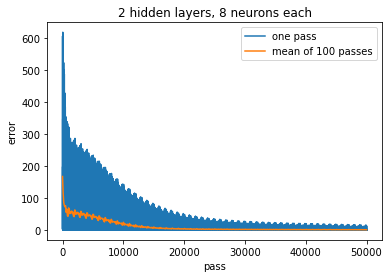

```
2 hidden layers, 16 neurons each, last mean error: 0.05819864763555945
```

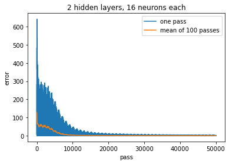

```
2 hidden layers, 32 neurons each, last mean error: 0.05400907684420433
```

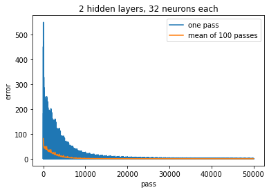

```
2 hidden layers, 64 neurons each, last mean error: 0.0727986359804967
```

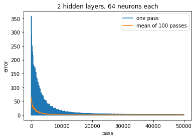

```
2 hidden layers, 128 neurons each, last mean error: 0.012107254685028176
```

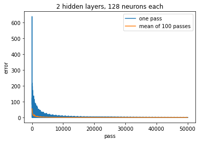

```
2 hidden layers, 256 neurons each, last mean error: 0.11073960339291819
```

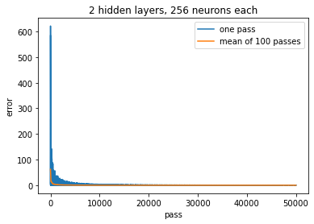

```
2 hidden layers, 512 neurons each, last mean error: 6.218799166711066e-05
```

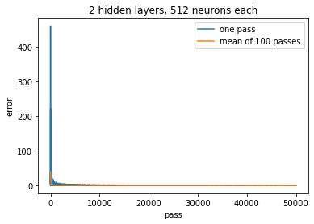

```python
layers = [[1, 1],
          [2, 2],
          [4, 4],
          [8, 8],
          [16, 16],
          [32, 32],
          [64, 64],
          [128, 128],
          [256, 256],
          [512, 512]]

for ind, layer_type in enumerate(layers):
    mlp = Perceptron(problem_type=Perceptron.ProblemType.Regression,
                     hidden_layers=layer_type,
                     activation=sigmoid,
                     dActivation=dSigmoid,
                     batch_size=3,
                     learning_rate=0.001,
                     momentum=0.1,
                     epochs=50,
                     bias=True)
    mlp.load("data\quadratic1_train.csv")
    losses = mlp.train()
    st = f'2 hidden layers, {2 ** ind} neurons each' if ind != 0 else f'2 hidden layers, {2 ** ind} neuron each'
    print(f'{st}, last mean error: {losses[-1]}')
    plot_errors_title(losses, st)
```

Providing the neural network with one additional layer seems to improve the final result in general but takes more time to execute.

## Loss function comparison

We will compare 3 loss functions: MSE (mean squared error), MAE (mean absolute error) and combination of Softmax activation with Cross entropy. MSE is a default loss function.

```
Success ratio: 0.9256333333333333
```

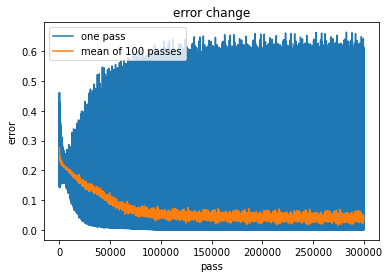

```
Last mean error: 0.04124787736697505
```

```python
mlp = Perceptron(problem_type=Perceptron.ProblemType.Classification,
                 hidden_layers=[3],
                 activation=sigmoid,
                 dActivation=dSigmoid,
                 final=sigmoid,
                 dFinal=dSigmoid,
                 loss=MSE,
                 dLoss=dMSE,
                 batch_size=3,
                 learning_rate=0.01,
                 momentum=0.1,
                 epochs=10,
                 bias=True)
mlp.load("data\data.three_gauss.train.10000.csv")
losses = mlp.train()
mlp.test_classification("data\data.three_gauss.test.10000.csv")
plot_errors(losses)
```

Model converges and provides us with satisfactory results. As we can see the learning curve is smooth and saturates in proximity of 150000th pass in spite of MSE's simple implementation.

```
Success ratio: 0.6123333333333333
```

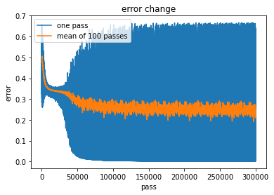

```
Last mean error: 0.24729673200550623
```

```python
mlp = Perceptron(problem_type=Perceptron.ProblemType.Classification,
                 hidden_layers=[3],
                 activation=sigmoid,
                 dActivation=dSigmoid,
                 final=sigmoid,
                 dFinal=dSigmoid,
                 loss=MAE,
                 dLoss=dMAE,
                 batch_size=3,
                 learning_rate=0.01,
                 momentum=0.1,
                 epochs=10,
                 bias=True)
mlp.load("data\data.three_gauss.train.10000.csv")
losses = mlp.train()
mlp.test_classification("data\data.three_gauss.test.10000.csv")
plot_errors(losses)
```

Model converges in significantly worse fashion than the previous one. Interestingly, we can notice dip in learning efficiency around 50000th pass. Moreover, achieved success ratio is only around 0.6 - way below standards, although somewhat positive.

```
Success ratio: 0.9283333333333333
```

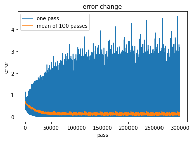

```
Last mean error: 0.1521442725350527
```

```python
mlp = Perceptron(problem_type=Perceptron.ProblemType.Classification,
                 hidden_layers=[3],
                 activation=sigmoid,
                 dActivation=dSigmoid,
                 SM_CE=True,
                 batch_size=3,
                 learning_rate=0.01,
                 momentum=0.1,
                 epochs=10,
                 bias=True)
mlp.load("data\data.three_gauss.train.10000.csv")
losses = mlp.train()
mlp.test_classification("data\data.three_gauss.test.10000.csv")
plot_errors(losses)
```

Combination of Cross entropy loss function and Softmax activation function gives good results. Learning curve saturates around 50000th sample - it is approximately 3 times 'faster' than MSE loss function.